# R Resultados de la evaluacion de VUELOS

# Introduction

```r
#, include=FALSE
library(modelr)
library(tidyverse)
library(nycflights13)
```

# Heading

## Sub-heading

### Another deeper heading

# Lists

- apples
- oranges
- pears
1. apples
2. oranges
3. pears

# Link

[link](http://example.com)

# Options for Chunck

## Cache

```r
for (i in 1:5000) {
    lm((i+1)~i)
}
```

## Echo

```
## [1] 0.8755234
```

## Include

# Output Types

## Console Output

```r
numbers <- seq_len(15)
numbers
```

```
##  [1]  1  2  3  4  5  6  7  8  9 10 11 12 13 14 15
```

Notice how the output appears right beneath the chunk, as though you’d run the code at the R console. Try changing the sequence length to 20 and re-running the chunk to see the result update.

## Graphical Output

Of course, sometimes your R code doesn’t just produce text; it produces graphical output such as plots. These are supported, too. Try running this chunk:

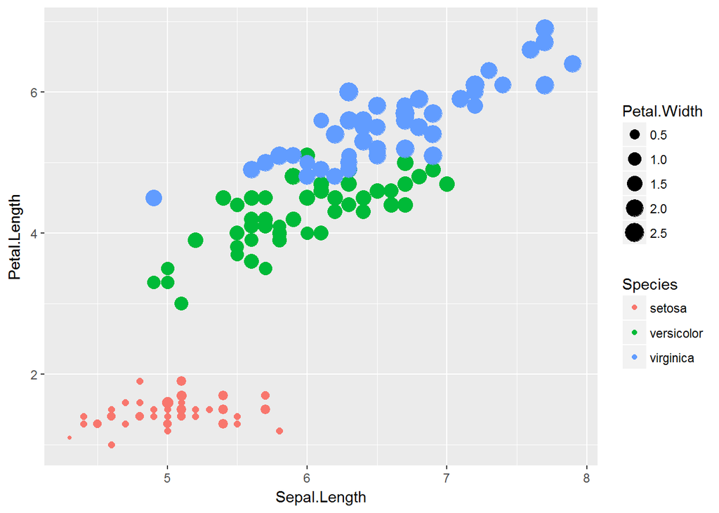

```r
ggplot(iris) +
  geom_point(aes(Sepal.Length, Petal.Length, color = Species, size = Petal.Width))
```

## MY Graphical Output

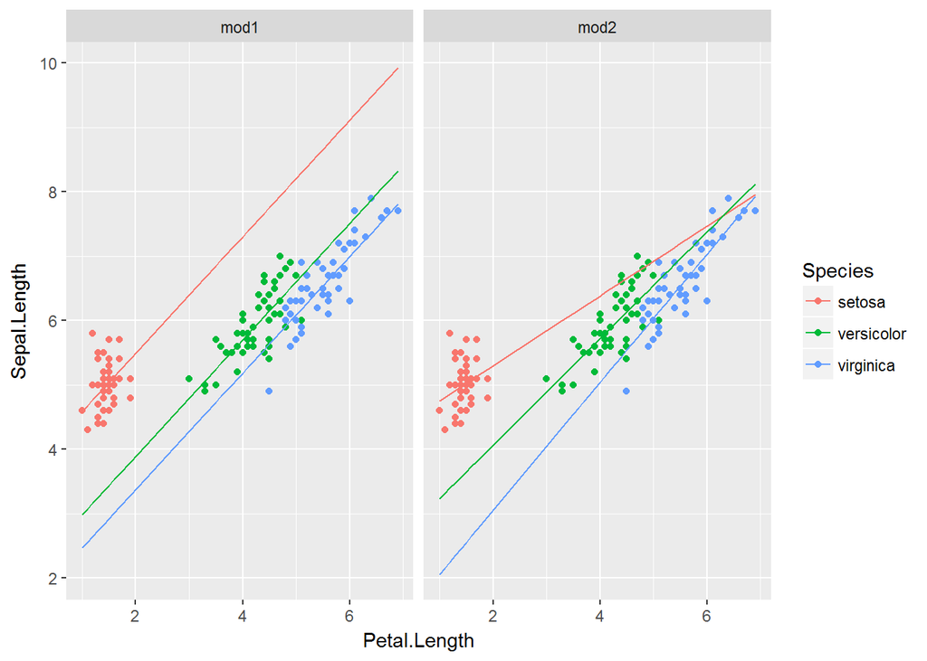

```r
mod1 <- lm( Sepal.Length ~ Petal.Length + Species, data = iris)
mod2 <- lm( Sepal.Length ~ Petal.Length * Species, data = iris)

mod3 <- lm( Sepal.Length ~ Sepal.Width + Species, data = iris)
mod4 <- lm( Sepal.Length ~ Sepal.Width * Species, data = iris)

mod5 <- lm( Petal.Length ~ Petal.Width + Species, data = iris)
mod6 <- lm( Petal.Length ~ Petal.Width * Species, data = iris)


mod7 <- lm( Petal.Width ~ Petal.Length + Species, data = iris)
mod8 <- lm( Petal.Width ~ Petal.Length * Species, data = iris)

grid <- iris %>%
  data_grid(Petal.Length, Species) %>%
  gather_predictions(mod1, mod2)

grid2 <- iris %>%
  data_grid(Sepal.Width, Species) %>%
  gather_predictions(mod3, mod4)

grid3 <- iris %>%
  data_grid(Petal.Width, Species) %>%
  gather_predictions(mod5, mod6)

grid4 <- iris %>%
  data_grid(Petal.Length, Species) %>%
  gather_predictions(mod7, mod8)

ggplot(iris, aes(Petal.Length, Sepal.Length, colour = Species)) +
  geom_point() +
  geom_line(data = grid, aes(y = pred)) +
  facet_wrap(~ model)
```

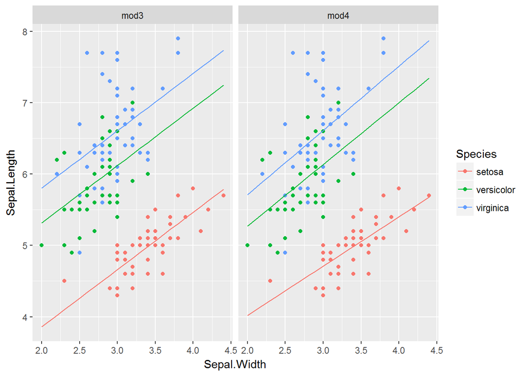

```r
ggplot(iris, aes(Sepal.Width, Sepal.Length, colour = Species)) +
  geom_point() +
  geom_line(data = grid2, aes(y = pred)) +
  facet_wrap(~ model)
```

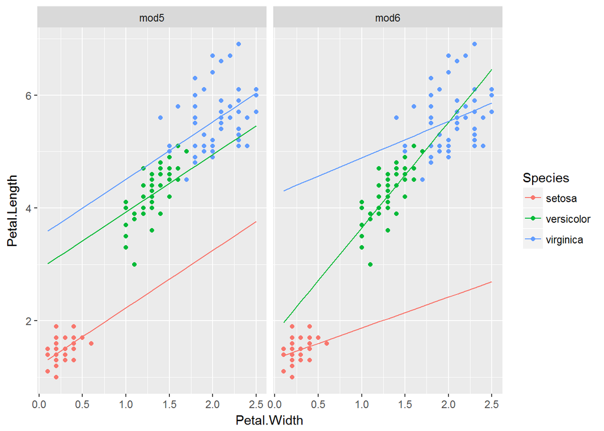

```r
ggplot(iris, aes(Petal.Width, Petal.Length, colour = Species)) +
  geom_point() +
  geom_line(data = grid3, aes(y = pred)) +
  facet_wrap(~ model)
```

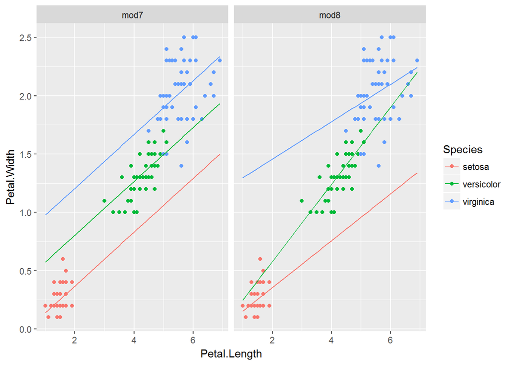

```r
ggplot(iris, aes(Petal.Length, Petal.Width, colour = Species)) +
  geom_point() +
  geom_line(data = grid4, aes(y = pred)) +
  facet_wrap(~ model)
```

# Running Code

One of the goals of the notebook is to provide a seamless environment for interacting with R – that is, you shouldn’t need to reach for the console, even though chunks send code there. To help you see the progress of your chunk – that is, which lines have been executed and which haven’t – RStudio draws an indicator in the editor gutter. Try running this chunk:

```r
Sys.sleep(1); runif(3)
```

```
## [1] 0.3048584 0.8467731 0.4475547
```

```r
Sys.sleep(1); runif(3)
```

```
## [1] 0.9668197 0.8698623 0.9951679
```

```r
Sys.sleep(1); runif(3)
```

```
## [1] 0.07837173 0.46697604 0.48119140
```

```r
Sys.sleep(1); runif(3)
```

```
## [1] 0.5308495 0.8097855 0.7205456
```

```r
Sys.sleep(1); runif(3)
```

```
## [1] 0.7034332 0.2409363 0.6946590
```

### Alternate Engines

Try using the [Feather](https://github.com/wesm/feather) package for R and Python to transfer data between them.

You can use a notebook to form an executable, documented workflow that composes several tools into a complete data analysis workflow.

## Errors

Sometimes your code will generate errors. Here’s an example:

```r
# Source a file that doesn't exist
source("missing.R")
```

```
## Error in file(filename, "r", encoding = encoding): no se puede abrir la conexión
```

Notice that the line that caused the error is highlighted, and you can see the error’s traceback, just as you can in the RStudio console. If an error occurs while you’re running chunks, the error will cause the notebook to stop running, and the cursor will scroll to the point where the error occurred.

# Tables

```r
library(nycflights13)
library(dplyr)
flights
```

```
## # A tibble: 336,776 x 19
##     year month   day dep_time sched_dep_time dep_delay arr_time
##    <int> <int> <int>    <int>          <int>     <dbl>    <int>
##  1  2013     1     1      517            515         2      830
##  2  2013     1     1      533            529         4      850
##  3  2013     1     1      542            540         2      923
##  4  2013     1     1      544            545        -1     1004
##  5  2013     1     1      554            600        -6      812
##  6  2013     1     1      554            558        -4      740
##  7  2013     1     1      555            600        -5      913
##  8  2013     1     1      557            600        -3      709
##  9  2013     1     1      557            600        -3      838
## 10  2013     1     1      558            600        -2      753
## # ... with 336,766 more rows, and 12 more variables: sched_arr_time <int>,
## #   arr_delay <dbl>, carrier <chr>, flight <int>, tailnum <chr>,
## #   origin <chr>, dest <chr>, air_time <dbl>, distance <dbl>, hour <dbl>,
## #   minute <dbl>, time_hour <dttm>
```

```r
flights %>%
  head(100) %>%
  knitr::kable()
```

| year | month | day | dep_time | sched_dep_time | dep_delay | arr_time | sched_arr_time | arr_delay | carrier | flight | tailnum | origin | dest | air_time | distance | hour | minute | time_hour |
| --- | --- | --- | --- | --- | --- | --- | --- | --- | --- | --- | --- | --- | --- | --- | --- | --- | --- | --- |
| 2013 | 1 | 1 | 517 | 515 | 2 | 830 | 819 | 11 | UA | 1545 | N14228 | EWR | IAH | 227 | 1400 | 5 | 15 | 2013-01-01 05:00:00 |
| 2013 | 1 | 1 | 533 | 529 | 4 | 850 | 830 | 20 | UA | 1714 | N24211 | LGA | IAH | 227 | 1416 | 5 | 29 | 2013-01-01 05:00:00 |
| 2013 | 1 | 1 | 542 | 540 | 2 | 923 | 850 | 33 | AA | 1141 | N619AA | JFK | MIA | 160 | 1089 | 5 | 40 | 2013-01-01 05:00:00 |
| 2013 | 1 | 1 | 544 | 545 | -1 | 1004 | 1022 | -18 | B6 | 725 | N804JB | JFK | BQN | 183 | 1576 | 5 | 45 | 2013-01-01 05:00:00 |
| 2013 | 1 | 1 | 554 | 600 | -6 | 812 | 837 | -25 | DL | 461 | N668DN | LGA | ATL | 116 | 762 | 6 | 0 | 2013-01-01 06:00:00 |
| 2013 | 1 | 1 | 554 | 558 | -4 | 740 | 728 | 12 | UA | 1696 | N39463 | EWR | ORD | 150 | 719 | 5 | 58 | 2013-01-01 05:00:00 |
| 2013 | 1 | 1 | 555 | 600 | -5 | 913 | 854 | 19 | B6 | 507 | N516JB | EWR | FLL | 158 | 1065 | 6 | 0 | 2013-01-01 06:00:00 |
| 2013 | 1 | 1 | 557 | 600 | -3 | 709 | 723 | -14 | EV | 5708 | N829AS | LGA | IAD | 53 | 229 | 6 | 0 | 2013-01-01 06:00:00 |
| 2013 | 1 | 1 | 557 | 600 | -3 | 838 | 846 | -8 | B6 | 79 | N593JB | JFK | MCO | 140 | 944 | 6 | 0 | 2013-01-01 06:00:00 |
| 2013 | 1 | 1 | 558 | 600 | -2 | 753 | 745 | 8 | AA | 301 | N3ALAA | LGA | ORD | 138 | 733 | 6 | 0 | 2013-01-01 06:00:00 |
| 2013 | 1 | 1 | 558 | 600 | -2 | 849 | 851 | -2 | B6 | 49 | N793JB | JFK | PBI | 149 | 1028 | 6 | 0 | 2013-01-01 06:00:00 |
| 2013 | 1 | 1 | 558 | 600 | -2 | 853 | 856 | -3 | B6 | 71 | N657JB | JFK | TPA | 158 | 1005 | 6 | 0 | 2013-01-01 06:00:00 |
| 2013 | 1 | 1 | 558 | 600 | -2 | 924 | 917 | 7 | UA | 194 | N29129 | JFK | LAX | 345 | 2475 | 6 | 0 | 2013-01-01 06:00:00 |
| 2013 | 1 | 1 | 558 | 600 | -2 | 923 | 937 | -14 | UA | 1124 | N53441 | EWR | SFO | 361 | 2565 | 6 | 0 | 2013-01-01 06:00:00 |
| 2013 | 1 | 1 | 559 | 600 | -1 | 941 | 910 | 31 | AA | 707 | N3DUAA | LGA | DFW | 257 | 1389 | 6 | 0 | 2013-01-01 06:00:00 |
| 2013 | 1 | 1 | 559 | 559 | 0 | 702 | 706 | -4 | B6 | 1806 | N708JB | JFK | BOS | 44 | 187 | 5 | 59 | 2013-01-01 05:00:00 |
| 2013 | 1 | 1 | 559 | 600 | -1 | 854 | 902 | -8 | UA | 1187 | N76515 | EWR | LAS | 337 | 2227 | 6 | 0 | 2013-01-01 06:00:00 |
| 2013 | 1 | 1 | 600 | 600 | 0 | 851 | 858 | -7 | B6 | 371 | N595JB | LGA | FLL | 152 | 1076 | 6 | 0 | 2013-01-01 06:00:00 |
| 2013 | 1 | 1 | 600 | 600 | 0 | 837 | 825 | 12 | MQ | 4650 | N542MQ | LGA | ATL | 134 | 762 | 6 | 0 | 2013-01-01 06:00:00 |
| 2013 | 1 | 1 | 601 | 600 | 1 | 844 | 850 | -6 | B6 | 343 | N644JB | EWR | PBI | 147 | 1023 | 6 | 0 | 2013-01-01 06:00:00 |
| 2013 | 1 | 1 | 602 | 610 | -8 | 812 | 820 | -8 | DL | 1919 | N971DL | LGA | MSP | 170 | 1020 | 6 | 10 | 2013-01-01 06:00:00 |
| 2013 | 1 | 1 | 602 | 605 | -3 | 821 | 805 | 16 | MQ | 4401 | N730MQ | LGA | DTW | 105 | 502 | 6 | 5 | 2013-01-01 06:00:00 |
| 2013 | 1 | 1 | 606 | 610 | -4 | 858 | 910 | -12 | AA | 1895 | N633AA | EWR | MIA | 152 | 1085 | 6 | 10 | 2013-01-01 06:00:00 |
| 2013 | 1 | 1 | 606 | 610 | -4 | 837 | 845 | -8 | DL | 1743 | N3739P | JFK | ATL | 128 | 760 | 6 | 10 | 2013-01-01 06:00:00 |
| 2013 | 1 | 1 | 607 | 607 | 0 | 858 | 915 | -17 | UA | 1077 | N53442 | EWR | MIA | 157 | 1085 | 6 | 7 | 2013-01-01 06:00:00 |
| 2013 | 1 | 1 | 608 | 600 | 8 | 807 | 735 | 32 | MQ | 3768 | N9EAMQ | EWR | ORD | 139 | 719 | 6 | 0 | 2013-01-01 06:00:00 |
| 2013 | 1 | 1 | 611 | 600 | 11 | 945 | 931 | 14 | UA | 303 | N532UA | JFK | SFO | 366 | 2586 | 6 | 0 | 2013-01-01 06:00:00 |
| 2013 | 1 | 1 | 613 | 610 | 3 | 925 | 921 | 4 | B6 | 135 | N635JB | JFK | RSW | 175 | 1074 | 6 | 10 | 2013-01-01 06:00:00 |
| 2013 | 1 | 1 | 615 | 615 | 0 | 1039 | 1100 | -21 | B6 | 709 | N794JB | JFK | SJU | 182 | 1598 | 6 | 15 | 2013-01-01 06:00:00 |
| 2013 | 1 | 1 | 615 | 615 | 0 | 833 | 842 | -9 | DL | 575 | N326NB | EWR | ATL | 120 | 746 | 6 | 15 | 2013-01-01 06:00:00 |

[output cut: 70 more lines]

# Saving and Sharing

A notebook’s source code is always in an `.Rmd` file. Whenever you save it, a sidecar `.nb.html` file is generated. This file contains a rendered copy of the notebook itself. No special viewer is required.

It also contains a copy of the notebook’s source `.Rmd` file.

To look at the `.nb.html` file, click *Preview* in the RStudio editor toolbar. This is a fundamental difference between notebooks and other R Markdown documents; pressing this button doesn’t actually cause any of your code to run, it just shows you the HTML file already prepared. It will automatically update whenever you save the `.Rmd` file.

If you open the `.nb.html` file in a web browser, you’ll see an option to download the source. You can also open an `.nb.html` file in RStudio; when you do this, RStudio will automatically extract the `.Rmd` file and outputs inside it and open the file in the notebook editor.

# Further reading

[R Notebook Reference](http://rmarkdown.rstudio.com/r_notebooks.html)